# td5_aymeric_noel_if5.R

Aymeric-PC

Thu Nov 07 11:10:01 2019

# TD 5 Aymeric NOEL IF 5

First we import the dataset using the library readr wich allows us to read a csv file

```r
setwd("C:/Users/Aymeric-PC/Desktop/Cours/machine learning")
library(MASS)
library(readr)
library(ROCR)
bank_marketing <- read.table(file="bank_marketing.csv",sep=";",header = TRUE)
str(bank_marketing)
```

```
## 'data.frame':    4521 obs. of  17 variables:
##  $ age      : int  30 33 35 30 59 35 36 39 41 43 ...
##  $ job      : Factor w/ 12 levels "admin.","blue-collar",..: 11 8 5 5 2 5 7 10 3 8 ...
##  $ marital  : Factor w/ 3 levels "divorced","married",..: 2 2 3 2 2 3 2 2 2 2 ...
##  $ education: Factor w/ 4 levels "primary","secondary",..: 1 2 3 3 2 3 3 2 3 1 ...
##  $ default  : Factor w/ 2 levels "no","yes": 1 1 1 1 1 1 1 1 1 1 ...
##  $ balance  : int  1787 4789 1350 1476 0 747 307 147 221 -88 ...
##  $ housing  : Factor w/ 2 levels "no","yes": 1 2 2 2 2 1 2 2 2 2 ...
##  $ loan     : Factor w/ 2 levels "no","yes": 1 2 1 2 1 1 1 1 1 2 ...
##  $ contact  : Factor w/ 3 levels "cellular","telephone",..: 1 1 1 3 3 1 1 1 3 1 ...
##  $ day      : int  19 11 16 3 5 23 14 6 14 17 ...
##  $ month    : Factor w/ 12 levels "apr","aug","dec",..: 11 9 1 7 9 4 9 9 9 1 ...
##  $ duration : int  79 220 185 199 226 141 341 151 57 313 ...
##  $ campaign : int  1 1 1 4 1 2 1 2 2 1 ...
##  $ pdays    : int  -1 339 330 -1 -1 176 330 -1 -1 147 ...
##  $ previous : int  0 4 1 0 0 3 2 0 0 2 ...
##  $ poutcome : Factor w/ 4 levels "failure","other",..: 4 1 1 4 4 1 2 4 4 1 ...
##  $ y        : Factor w/ 2 levels "no","yes": 1 1 1 1 1 1 1 1 1 1 ...
```

As we can see we have 17 variables, some are quantitative, other qualitatives

```r
summary(bank_marketing)
```

```
##       age                 job          marital         education
##  Min.   :19.00   management :969   divorced: 528   primary  : 678
##  1st Qu.:33.00   blue-collar:946   married :2797   secondary:2306
##  Median :39.00   technician :768   single  :1196   tertiary :1350
##  Mean   :41.17   admin.     :478                   unknown  : 187
##  3rd Qu.:49.00   services   :417
##  Max.   :87.00   retired    :230
##                  (Other)    :713
##  default       balance      housing     loan           contact
##  no :4445   Min.   :-3313   no :1962   no :3830   cellular :2896
##  yes:  76   1st Qu.:   69   yes:2559   yes: 691   telephone: 301
##             Median :  444                         unknown  :1324
##             Mean   : 1423
##             3rd Qu.: 1480
##             Max.   :71188
##
##       day            month         duration       campaign
##  Min.   : 1.00   may    :1398   Min.   :   4   Min.   : 1.000
##  1st Qu.: 9.00   jul    : 706   1st Qu.: 104   1st Qu.: 1.000
##  Median :16.00   aug    : 633   Median : 185   Median : 2.000
##  Mean   :15.92   jun    : 531   Mean   : 264   Mean   : 2.794
##  3rd Qu.:21.00   nov    : 389   3rd Qu.: 329   3rd Qu.: 3.000
##  Max.   :31.00   apr    : 293   Max.   :3025   Max.   :50.000
##                  (Other): 571
##      pdays           previous          poutcome      y
##  Min.   : -1.00   Min.   : 0.0000   failure: 490   no :4000
##  1st Qu.: -1.00   1st Qu.: 0.0000   other  : 197   yes: 521
##  Median : -1.00   Median : 0.0000   success: 129
##  Mean   : 39.77   Mean   : 0.5426   unknown:3705
##  3rd Qu.: -1.00   3rd Qu.: 0.0000
##  Max.   :871.00   Max.   :25.0000
##
```

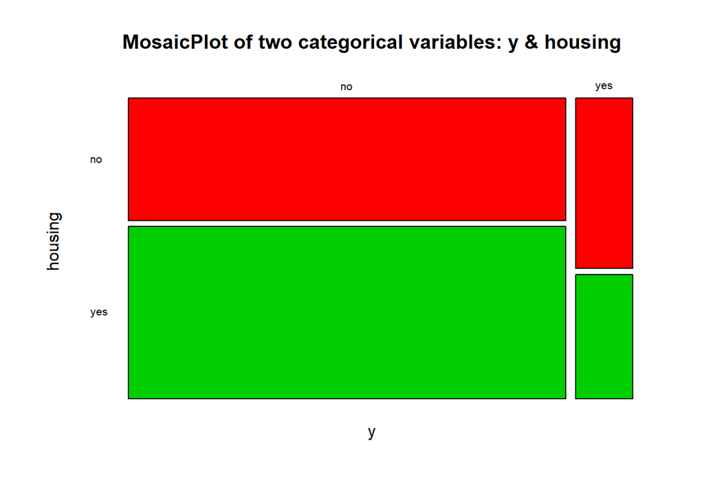

```r
mosaicplot(~ y + housing, data=bank_marketing,main = "MosaicPlot of two categorical variables: y & housing",color = 2:3, las = 1)
```

[figure not shown]

```r
mosaicplot(~ y + contact, data=bank_marketing,main = "MosaicPlot of two categorical variables: y & housing",color = 2:3, las = 1)
```

```r
chisq.test(bank_marketing$housing,bank_marketing$contact)
```

```
##
##  Pearson's Chi-squared test
##
## data:  bank_marketing$housing and bank_marketing$contact
## X-squared = 216.68, df = 2, p-value < 2.2e-16
```

```r
chisq.test(bank_marketing$campaign,bank_marketing$duration)
```

```
##
##  Pearson's Chi-squared test
##
## data:  bank_marketing$campaign and bank_marketing$duration
## X-squared = 24651, df = 27094, p-value = 1
```

```r
chisq.test(bank_marketing$housing,bank_marketing$contact)
```

```
##
##  Pearson's Chi-squared test
##
## data:  bank_marketing$housing and bank_marketing$contact
## X-squared = 216.68, df = 2, p-value < 2.2e-16
```

```r
chisq.test(bank_marketing$duration,bank_marketing$housing)
```

```
##
##  Pearson's Chi-squared test
##
## data:  bank_marketing$duration and bank_marketing$housing
## X-squared = 871.53, df = 874, p-value = 0.5172
```

```r
library(caTools)
set.seed(700173)
split = sample.split(bank_marketing$y, SplitRatio = 0.75)
training_set = subset(bank_marketing, split == TRUE)
test_set = subset(bank_marketing, split == FALSE)
```

To split the dataset we use the function split with a ratio of 0.75%

```r
model_lda=lda(y~campaign*balance+duration, data=training_set)
```

Our first model is a lda model (linear discriminant analysis)

```r
summary(model_lda)
```

```
##         Length Class  Mode
## prior   2      -none- numeric
## counts  2      -none- numeric
## means   8      -none- numeric
## scaling 4      -none- numeric
## lev     2      -none- character
## svd     1      -none- numeric
## N       1      -none- numeric
## call    3      -none- call
## terms   3      terms  call
## xlevels 0      -none- list
```

```r
pred_lda = predict(model_lda, newdata = test_set[,-17])
prediction_lda=pred_lda$class
cmlda = table(prediction_lda, test_set[,17])
cmlda
```

```
##
## prediction_lda  no yes
##            no  977 100
##            yes  23  30
```

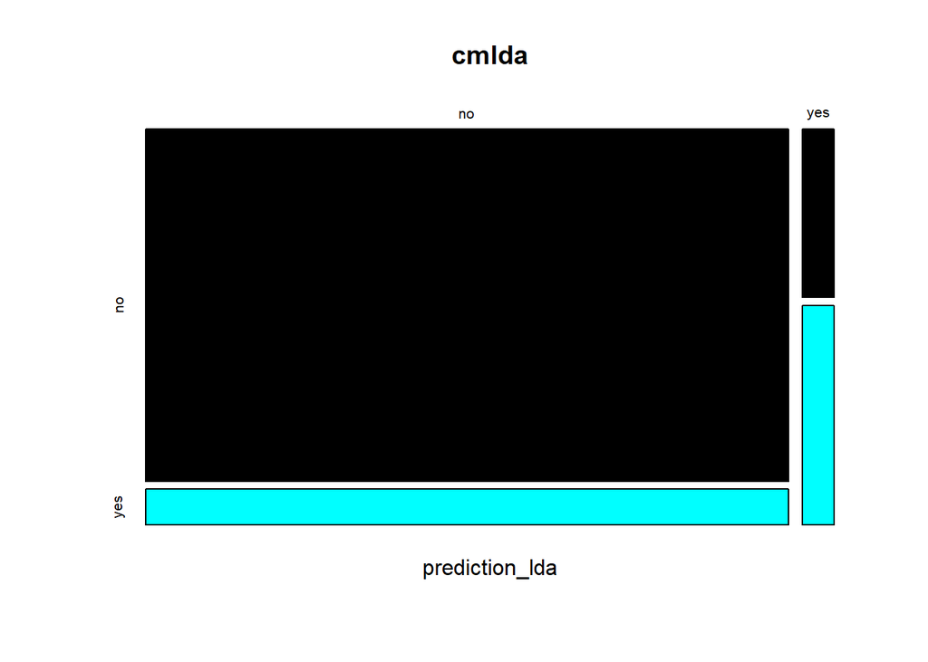

```r
mosaicplot(cmlda,col=sample(1:8,2))
```

Our model isn’t perfect because as we can see in the confusion matrix, we have only true yes (predicted yes which is actually a real yes)

```r
AnalyseMatrix<-function(x){
  accuracy <-(x[1,1]+x[2,2])/sum(x)
  cat("accuracy : ")
  print(accuracy)
  precision<-x[1,1]/(x[1,1]+x[2,1])
  cat("precision : ")
  print(precision)
  sensitivity<- x[1,1]/(x[1,1]+x[1,2])
  cat("sensitivity :")
  print(sensitivity)
  specificity<-x[2,2]/(x[2,2]+x[1,2])
  cat("specificity : ")
  print(specificity)
}
AnalyseMatrix(cmlda)
```

```
## accuracy : [1] 0.8911504
## precision : [1] 0.977
## sensitivity :[1] 0.9071495
## specificity : [1] 0.2307692
```

We can see here that the accuracy is 0.89 %, that is we have 0.89% of good predictions

```r
model_qda <- qda(y~campaign*balance+duration, data=training_set)
```

Let’s compute a qda model (Quadratic Discriminant Analysis)

```r
summary(model_qda)
```

```
##         Length Class  Mode
## prior    2     -none- numeric
## counts   2     -none- numeric
## means    8     -none- numeric
## scaling 32     -none- numeric
## ldet     2     -none- numeric
## lev      2     -none- character
## N        1     -none- numeric
## call     3     -none- call
## terms    3     terms  call
## xlevels  0     -none- list
```

```r
pred_qda = predict(model_qda, newdata = test_set[,-17])
prediction_qda=pred_qda$class
cmqda = table(prediction_qda, test_set[,17])
cmqda
```

```
##
## prediction_qda  no yes
##            no  935  86
##            yes  65  44
```

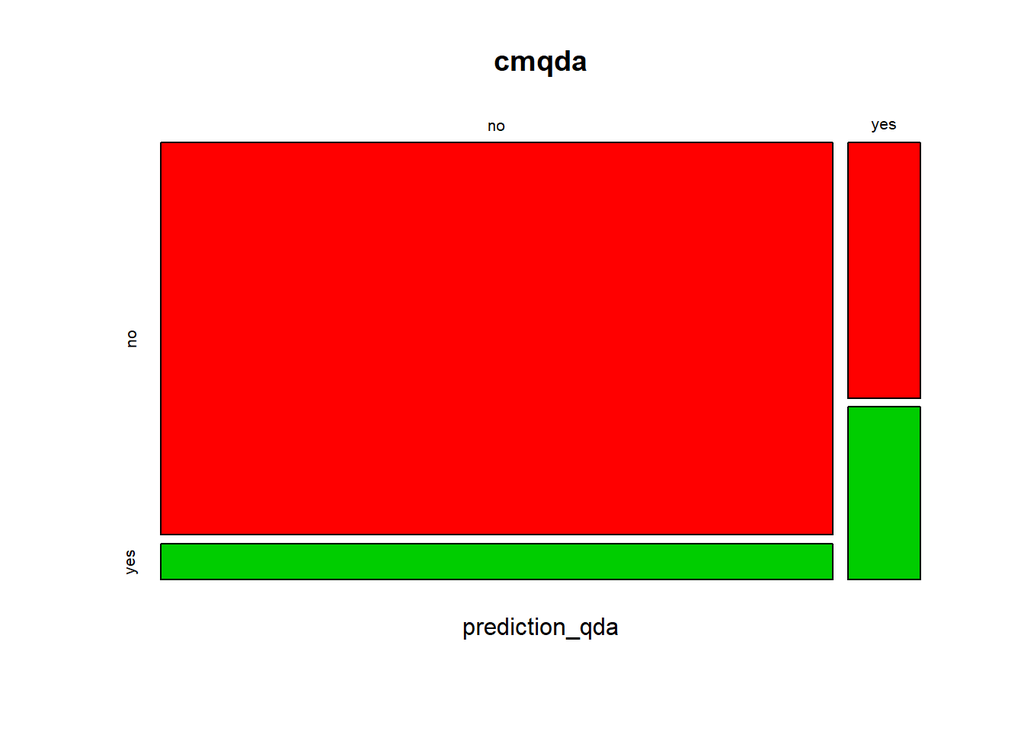

```r
mosaicplot(cmqda,col=sample(1:8,2))
```

This predictor seems better. Let’s compute the accuracy, the precision, the sensitivity and the specificity to have more informations.

```r
AnalyseMatrix(cmqda)
```

```
## accuracy : [1] 0.8663717
## precision : [1] 0.935
## sensitivity :[1] 0.9157689
## specificity : [1] 0.3384615
```

At final, the accuracy is lower than the previous model, 0.86 % of good predictions for the qda model and 0.89 for the lda model, so lda seems a better predictor.

Let’s compute the ROCR curves about our two models.

```r
score.lda <- prediction(pred_lda$posterior[,2],test_set[,17])
score.qda <- prediction(pred_qda$posterior[,2],test_set[,17])
performance(score.lda,"auc") # y.values
```

```
## An object of class "performance"
## Slot "x.name":
## [1] "None"
##
## Slot "y.name":
## [1] "Area under the ROC curve"
##
## Slot "alpha.name":
## [1] "none"
##
## Slot "x.values":
## list()
##
## Slot "y.values":
## [[1]]
## [1] 0.8265154
##
##
## Slot "alpha.values":
## list()
```

```r
plot(performance(score.lda,"tpr","fpr"),col="green")
performance(score.qda,"auc") # y.values
```

```
## An object of class "performance"
## Slot "x.name":
## [1] "None"
##
## Slot "y.name":
## [1] "Area under the ROC curve"
##
## Slot "alpha.name":
## [1] "none"
##
## Slot "x.values":
## list()
##
## Slot "y.values":
## [[1]]
## [1] 0.7795615
##
##
## Slot "alpha.values":
## list()
```

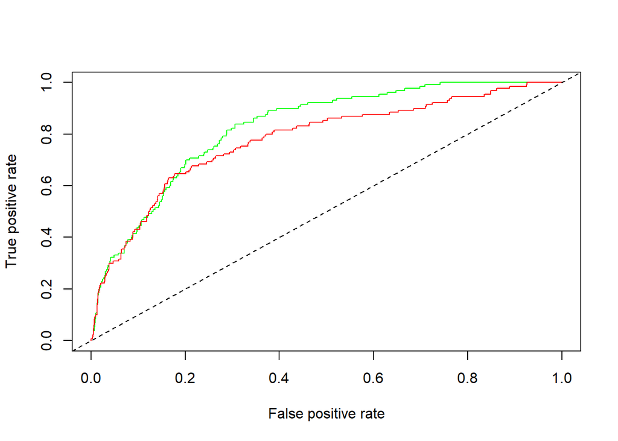

```r
plot(performance(score.qda,"tpr","fpr"),col="red",add=T)
abline(0,1,lty=8)
```

The red curve is the qda predictor and the green one is the lda predictor The red curve is under the green one, that is comfirms that the lda model is better

```r
AUC.scorelda=performance(score.lda,"auc")@y.values[[1]]
AUC.scorelda
```

```
## [1] 0.8265154
```

```r
AUC.scoreqda=performance(score.qda,"auc")@y.values[[1]]
AUC.scoreqda
```

```
## [1] 0.7795615
```

To conclude, let’s test a final model with multiples predictors : campaign*duration, poutcome and month. These variables are all dependents. Let’s compute an lda model because it seems better in our case.

```r
model_lda2 <- lda(y~campaign*duration+poutcome+month, data=training_set)
summary(model_lda2)
```

```
##         Length Class  Mode
## prior    2     -none- numeric
## counts   2     -none- numeric
## means   34     -none- numeric
## scaling 17     -none- numeric
## lev      2     -none- character
## svd      1     -none- numeric
## N        1     -none- numeric
## call     3     -none- call
## terms    3     terms  call
## xlevels  2     -none- list
```

```r
pred_lda2 = predict(model_lda2, newdata = test_set[,-17])
prediction_lda2=pred_lda2$class
cmqla2 = table(prediction_lda, test_set[,17])
cmqla2
```

```
##
## prediction_lda  no yes
##            no  977 100
##            yes  23  30
```

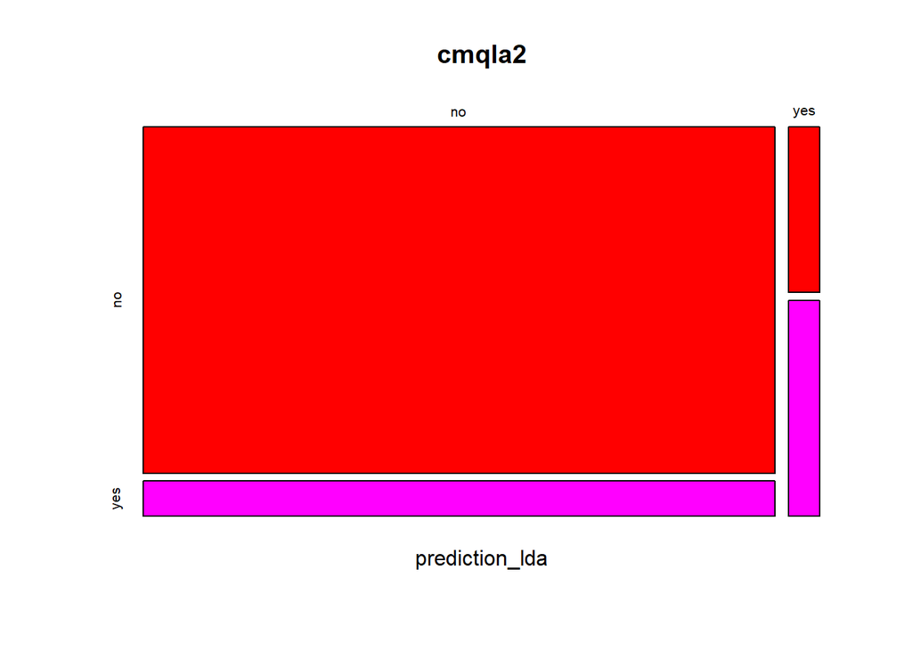

```r
mosaicplot(cmqla2,col=sample(1:8,2))
```

```r
AnalyseMatrix(cmqla2)
```

```
## accuracy : [1] 0.8911504
## precision : [1] 0.977
## sensitivity :[1] 0.9071495
## specificity : [1] 0.2307692
```

```r
score.lda2 <- prediction(pred_lda2$posterior[,2],test_set[,17])
AUC.scorelda2=performance(score.lda2,"auc")@y.values[[1]]
AUC.scorelda2
```

```
## [1] 0.8929731
```

We have an AUC of 0.89, so our new model is quite good, better than our previous models.

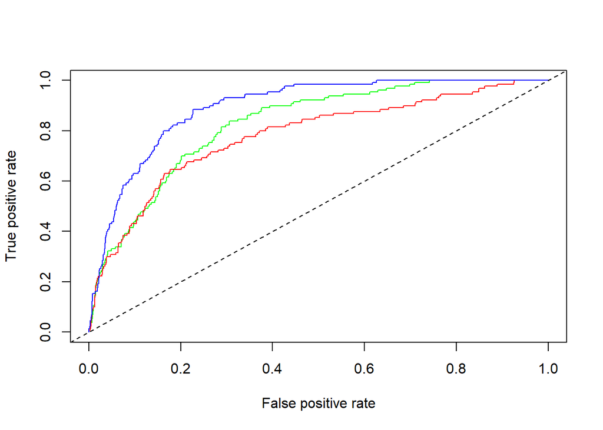

```r
plot(performance(score.lda,"tpr","fpr"),col="green")
plot(performance(score.qda,"tpr","fpr"),col="red",add=T)
plot(performance(score.lda2,"tpr","fpr"),col="blue",add=T)
abline(0,1,lty=8)
```

This confirms that the last model lda (the blue curve) is better.